# BA Individual Assignment

BA teaching team

# Assignment 1 **(40 points)**

**A survey of 219 patients collected their gender, medical costs, and ratings of service quality in a hospital. Let’s explore the medical cost patterns in data file “hospital.xlsx”.**

### **1.Calculate and compare the range, IQR, variance, and standard deviation of Service attitude and Doctor’s professional level. Explain what the results tell you about their distributions. （10 points）**

```r
library(readxl)
library(dplyr)
hospital <- read_excel("hospital.xlsx")
head(hospital)
```

```
## # A tibble: 6 × 5
##      ID Gender `Medicine costs` `Service attitude` `Doctor's professional level`
##   <dbl>  <dbl>            <dbl>              <dbl>                         <dbl>
## 1     1      0               40                  7                             6
## 2     2      0               29                  6                             6
## 3     3      0               30                  6                             6
## 4     4      0               38                  7                             7
## 5     5      0               30                  7                             7
## 6     6      0               33                  7                             7
```

```r
names(hospital)
```

```
## [1] "ID"                          "Gender"
## [3] "Medicine costs"              "Service attitude"
## [5] "Doctor's professional level"
```

```r
str(hospital)
```

```
## tibble [219 × 5] (S3: tbl_df/tbl/data.frame)
##  $ ID                         : num [1:219] 1 2 3 4 5 6 7 8 9 10 ...
##  $ Gender                     : num [1:219] 0 0 0 0 0 0 0 0 0 0 ...
##  $ Medicine costs             : num [1:219] 40 29 30 38 30 33 37 37 35 27 ...
##  $ Service attitude           : num [1:219] 7 6 6 7 7 7 5 6 6 7 ...
##  $ Doctor's professional level: num [1:219] 6 6 6 7 7 7 4 6 7 4 ...
```

```r
range_service <- range(hospital$`Service attitude`)
range_doctor  <- range(hospital$`Doctor's professional level`)

IQR_service <- IQR(hospital$`Service attitude`)
IQR_doctor  <- IQR(hospital$`Doctor's professional level`)

var_service <- var(hospital$`Service attitude`)
var_doctor  <- var(hospital$`Doctor's professional level`)

sd_service <- sd(hospital$`Service attitude`)
sd_doctor  <- sd(hospital$`Doctor's professional level`)

library(knitr)
result_table <- data.frame(
  Measure = c("Range", "IQR", "Variance", "SD"),
  Service_Attitude = c(diff(range_service), IQR_service, var_service, sd_service),
  Doctor_Professional_Level = c(diff(range_doctor), IQR_doctor, var_doctor, sd_doctor)
)

kable(result_table, caption = "Comparison of Variability Measures for Two Service Ratings")
```

Comparison of Variability Measures for Two Service Ratings

| Measure | Service_Attitude | Doctor_Professional_Level |
| --- | --- | --- |
| Range | 4.0000000 | 3.0000000 |
| IQR | 1.0000000 | 1.0000000 |
| Variance | 0.6230992 | 0.5499560 |
| SD | 0.7893663 | 0.7415902 |

answer: The service attitude range is 4, meaning some patients give high scores while others give low ones. There is significant variation in this evaluation. Doctor Professional Level is 3, indicating a relatively small gap between the highest and lowest scores, with most scores being closer together. The range for Service Attitude is slightly wider than that for Doctor Professional Level, because 4>3. But they both share the same IQR of 1, indicating that the middle 50% of responses suggest relatively consistent feedback and that the distributions are concentrated. The distributions are both highly clustered, as their variances and SD values are less than 1.0, indicating that the ratings are highly clustered, with most scores falling within a narrow numerical range. However, the 0.62 variance and 0.79 SD for service attitude are slightly higher than the Doctor Professional Level’s 0.55 and 0.74, respectively, meaning that patients’ perceptions of service attitude exhibit greater variability.

### **2. Create a histogram of Medicine costs, using a bin width of 5 (i.e., each group covers a 5-unit interval). What is the shape of the distribution? (10 points)**

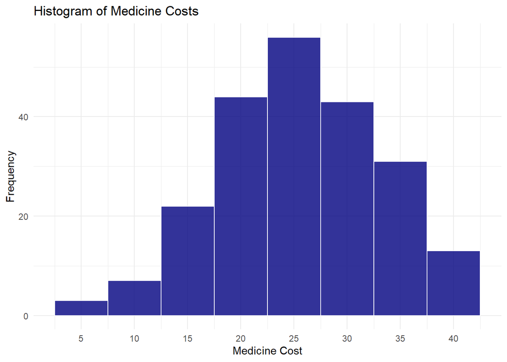

```r
library(ggplot2)
hospital <- read_excel("hospital.xlsx")

ggplot(hospital, aes(x = `Medicine costs`)) +
  geom_histogram(binwidth = 5, fill = "navy", color = "white", alpha = 0.8) +
  labs(
    title = "Histogram of Medicine Costs",
    x = "Medicine Cost",
    y = "Frequency"
  ) +
  theme_minimal() +
  scale_x_continuous(breaks = seq(0, 45, by = 5))
```

```r
median_cost <- median(hospital$`Medicine costs`, na.rm = TRUE)
cat("median_cost:", median_cost, "\n")
```

```
## median_cost: 27
```

```r
mean_cost <- mean(hospital$`Medicine costs`, na.rm = TRUE)
cat("mean_cost:", round(mean_cost, 2), "\n")
```

```
## mean_cost: 25.65
```

### **3.Use R to calculate the average Medicine costs for each gender (0 = Male, 1 = Female). What is the difference between the two groups? （10 points）**

```r
avg_costs <- hospital %>%
  group_by(Gender) %>%
  summarise(avg_medicine_cost = mean(`Medicine costs`, na.rm = TRUE),
            Sample_Size = n(),.groups = "drop")
gender_diff <- diff(avg_costs$Avg_Costs)
avg_costs
```

```
## # A tibble: 2 × 3
##   Gender avg_medicine_cost Sample_Size
##    <dbl>             <dbl>       <int>
## 1      0              25.4         124
## 2      1              25.9          95
```

### **4. Use R to calculate the 25th, 50th, and 75th percentiles of Medicine costs. What does this tell you about the cost distribution?（10 points）**

```r
percentiles <- quantile(hospital$`Medicine costs`, probs = c(0.25, 0.5, 0.75), na.rm = TRUE)
print(percentiles)
```

```
## 25% 50% 75%
##  20  27  31
```

```r
quantiles <- quantile(hospital$`Medicine costs`, probs = c(0.25, 0.75), na.rm = TRUE)
IQR_manual <- quantiles[2] - quantiles[1]
IQR_manual
```

```
## 75%
##  11
```

```r
library(dplyr)
library(tidyverse)
SalesPerformance <- read.csv("SalesPerformance.csv")
head(SalesPerformance)
```

```
##   OrderID CustomerID       Date Region ProductCategory Revenue    Profit
## 1    1001       C101  2024/6/28   East     Electronics 1770.23    -20.94
## 2    1002       C102 2023/12/14   West        Clothing 1659.64 167000.37
## 3    1003       C103 2024/12/13   West     Electronics      NA    212.81
## 4    1004       C104  2023/11/2   East     Electronics 1465.64    258.14
## 5    1005       C105 2024/11/28   West     Electronics 2224.30    334.04
## 6    1006       C106 2023/10/26   West       Furniture 1579.85    453.63
##   MarketingSpend
## 1         199.47
## 2         191.74
## 3         243.81
## 4         132.62
## 5          46.36
## 6         172.74
```

```r
names(SalesPerformance)
```

```
## [1] "OrderID"         "CustomerID"      "Date"            "Region"
## [5] "ProductCategory" "Revenue"         "Profit"          "MarketingSpend"
```

```r
SalesPerformance_clean <- SalesPerformance %>% distinct()
write.csv(SalesPerformance_clean, "SalesPerformance_clean.csv", row.names = FALSE)
cat("Original rows:", nrow(SalesPerformance), "\n")
```

```
## Original rows: 53
```

```r
cat("After removing duplicates:", nrow(SalesPerformance_clean), "\n")
```

```
## After removing duplicates: 50
```

1b) Handle Missing Values in “Revenue” (5 pts) Task: Impute missing values in the Revenue column of the SalesPerformance_clean.csv dataset using the median value. Saves the processed data as SalesPerformance_impute.csv.Explain why median imputation is appropriate here.

```r
SalesPerformance_clean <- read.csv("SalesPerformance_clean.csv")

revenue_median <- median(SalesPerformance_clean$Revenue, na.rm = TRUE)
cat("Median revenue used for imputation:", revenue_median, "\n")
```

```
## Median revenue used for imputation: 1551.205
```

```r
sales_imp  <- SalesPerformance_clean %>%
  mutate(Revenue = replace_na(Revenue, revenue_median))

SalesPerformance_clean$Revenue[is.na(SalesPerformance_clean$Revenue)] <- revenue_median

write.csv(SalesPerformance_clean, "SalesPerformance_impute.csv", row.names = FALSE)
```

Explanation: When revenue data may contain extreme outliers, the median is more suitable for filling gaps than the mean, as it is less affected by outliers and represents the middle value of the data, making it more robust. Therefore, when values are deviated or outliers, Median imputation will not distort the data’s structure, maintain the original data’s structure, and centralized data estimates are more robust.

1c) Detect & Treat Outliers in “Profit” (5 pts) Task: Write R code to identify outliers in the Profit column of the SalesPerformance_impute.csv dataset.Propose and implement a treatment method.Saves the processed data as SalesPerformance_outlier.csv. Justify your choice.

```r
library(ggplot2)
SalesPerformance_impute <- read.csv("SalesPerformance_impute.csv")

Q1 <- quantile(SalesPerformance_impute$Profit, 0.25, na.rm = TRUE)
Q3 <- quantile(SalesPerformance_impute$Profit, 0.75, na.rm = TRUE)
IQR <- Q3 - Q1
lower_bound <- Q1 - 1.5 * IQR
upper_bound <- Q3 + 1.5 * IQR

outliers <- SalesPerformance_impute$Profit < lower_bound | SalesPerformance_impute$Profit > upper_bound
cat("Number of outliers in Profit:", sum(outliers, na.rm = TRUE), "\n")
```

```
## Number of outliers in Profit: 2
```

```r
sales_outlier <- SalesPerformance_impute %>%
   mutate(Profit = ifelse(Profit < lower_bound, lower_bound,
                  ifelse(Profit > upper_bound, upper_bound, Profit)))

write.csv(sales_outlier, "SalesPerformance_outlier.csv", row.names = FALSE)
```

Justification: I chose IQR for outliers because it is robust for non-normal distributions. It will not be affected by outliers a lot, it can narrow the impact of outliers, and it is more flexible than fixed percentiles. For treatment, I used Winsorization method rather than delete directly because it can keep the data points and keep the sample integrity. The method replaces the outliers with upper and lower boundaries and keeps the structure of data by keeping all observations. Only limits the impact of extreme values.